# Machine Learning Study: Weightlifting Form Identification

Submitted by Andrew Chang on Jun 10 2020 for the Johns Hopkins Practical Machine Learning course

## Overview of the Study

The purpose of this study was to train a model that could identify a specific exercise movement based on kinematic (accelerometer and gyroscopic) measurements and evaluate its predictive ability on a test set of 20 observations. The study determined relevant features extracted from a set of 160 candidate features that were associated with kinematic movements, ultimately arriving at a set of 52 features as viable predictors for model fitting. In the course of identification, a set of highly correlated predictors were flagged out of the set of viable predictors to better inform model selection decisions regarding bias-reduction/variance-increase trade-offs at a later stage, for either Principal Components Analysis (PCA) or outright elimination. The study then trained three models corresponding to datasets that (1) included all variables, (2) excluded high-correlate variables, and (3) preprocessing the variables via PCA.

To achieve **cross-validation** and an evaluation stage prior to the ultimate validation of the model, the original test set was set aside as the validation set and in its stead 40% of the training model was assigned as the official test set. The training was run and evaluated three different times, with each iteration being built on a newly arranged partition. The training parameters of the three aforementioned models were then set for an out of sample error of at most 5%. Since the final validation of models is comprised of 20 trials, the predicted error rate would likely have to be less than 5% for the model to reliably predict all 20 trials. However, the PCA-preprocessed predictors might not be as successful at eliminating bias and the error rate could be an order of magnitude higher. In any case, the **out-of-sample error** from the three different models was estimated under the **Model Cross-validation and Selection** selection. A casual hypothesis of the study is that simple linear regression would be insufficient to categorize the movement. The random forest algorithm was chosen because of its accuracy in prediction, which was the primary objective of the study. The downsides involved with random forest algorithm were considered, but ultimately overridden since in at least the PCA model interpretability would be an issue regardless, speed is not an issue, and parameter-setting and cross validation measures had already been taken to ameliorate overfitting. After the preliminary internal testing, the accuracy of three models was then compared and one was selected to identify the 20 exercise movements.

## Synopsis of the Data and Cleaning Steps

Upon a cursory glance of the data using `str()`, the study found there were nearly 20 thousand observations in the original training set across 160 fields. `str()` also revealed that many of these fields contained either empty strings or `NA`s which in addition to the poor discrimination that a field with low variance offers most models, would probably cause the random forest algorithm some problems. Several of these fields were non-numeric and if they could not be factorized, they would offer more noise than signal to the random forest algorithm the study would be utilizing. Similarly, the fields `X` (observation number), `user_name` and those containing `timestamp` and `window` were deemed has metrics that were not useful toward distinguishing exercise motions across research subjects or time of recording. In addition `complete.cases()` showed that owing to the missing values, only 406 (just over 2%) of observations were complete. To deal with these and other problematic fields, the study produced a series of 160-long boolean vectors to denote which fields to retain, as well as note the index of the estimand, **classe**. Filtering on these boolean vectors, the original training and testing sets were reduced to 53 fields (including **classe**), denoted `liftTrain_trim` and `liftTest_trim`. Next, **classe** from the training set was factorized, with its labels re-attached and its index within the reduced data frame noted again for future reference. The training set with the factorized **classe** variable was then saved as `liftTrain_factor`.

## Assumptions, Preparation, and Procedure

To preserve the test set as the ultimate validation set, the study then assigned `liftTest_trim` to validation set `liftVal` and partitioned `liftTrain_factor` into the actual training (`liftTrain_ML` comprising 60% of the original) and test (`liftTest_ML` comprising 40%) sets, to which the study will hence refer as the cleaned datasets.

Screening for high correlates between the predictors and the estimand and plotting the results showed a few incidences above 0.2 in either direction and a mode of 0, meaning that none of the 52 remaining variables, when taken as a sole input, predicted the estimand well.

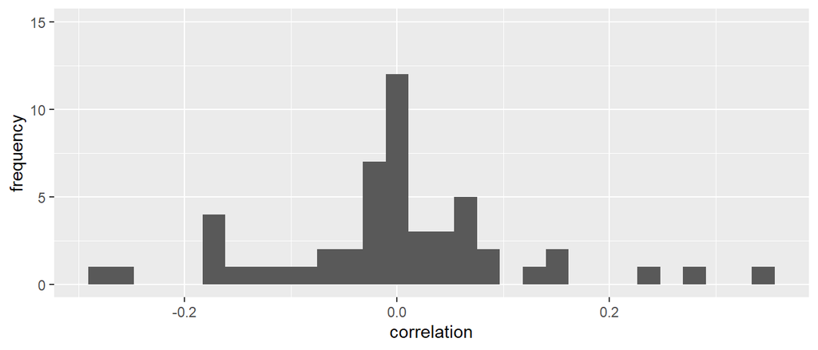

Filtering on these 5 columns and performing a linear regression yielded an adjusted R<sup>2</sup> of 0.223, signifying that even when taken together, the 5 highest correlates explained very little of the variation within the estimator and confirming our hypothesis that proceeding with merely a linear regression would yield very poor results. Turning to intra-feature correlations yielded a heatmap that implies high correlates among the potential features, which lent credence to the potential for the predictors to be either eliminated, or combined and thereby reduced in number via Principal Components Analysis in a way that would remove as much bias as they would otherwise have if included in their entirety at face value, but without the attendant increases to variance.

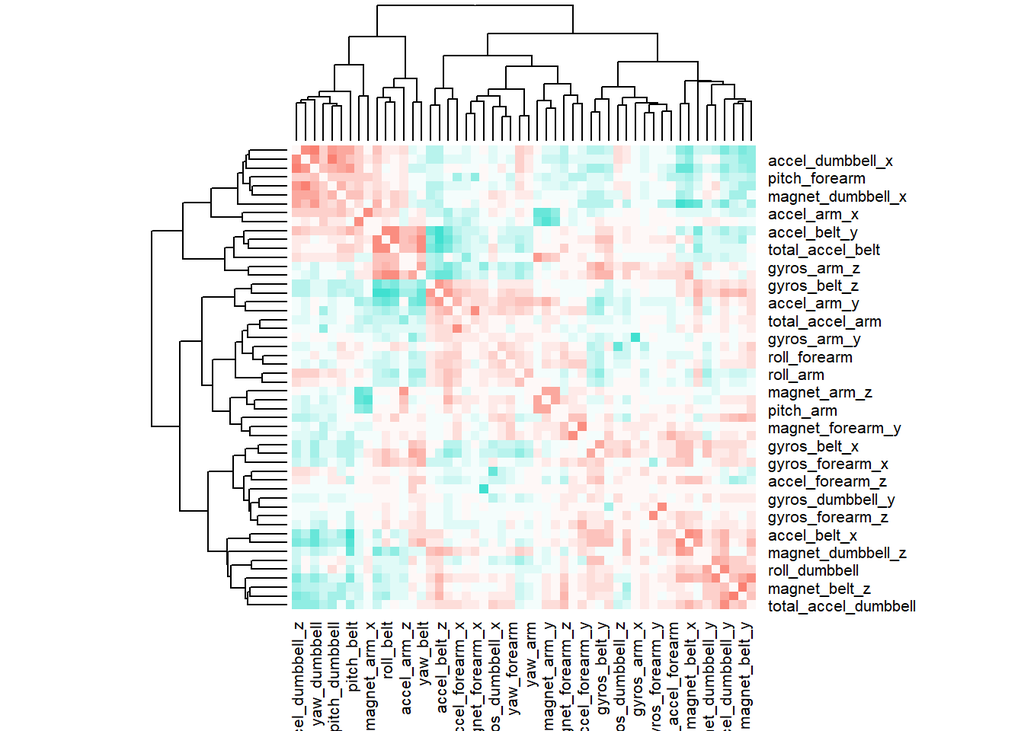

Accordingly the high intra-feature correlates above 0.8 were flagged. Theoretically the main ways to deal with these correlates were to (a) exclude them entirely, or (b) leave them in, but streamline their contribution to the model through PCA. Next, principal Components Analysis was performed in an attempt to winnow redundant predictors. The transformation was applied in like manner to the training, testing, and validation sets after excluding the **classe** column in each (although it should be noted the validation set’s 53rd column was not **classe**, but row number and therefore excluded from the PCA to reduce noise). Because the optimal number of components was unknown, the study instead opted to specify a threshold variance for the preprocessing to retain, as shown in the code below:

```r
set.seed(421337)

for(i in 1:3) {
        liftPart <- createDataPartition(y = liftTrain_factor$classe, p = part_prop, list = FALSE)
        liftTrain_ML <- liftTrain_factor[liftPart, ]
        liftTest_ML <- liftTrain_factor[-liftPart, ]

        liftTrain_prePCA <- preProcess(liftTrain_ML[, -classeColInd], method = "pca", thresh = 0.999)
        liftTrain_PCA <- predict(liftTrain_prePCA, liftTrain_ML[, -classeColInd])
        liftTest_PCA <- predict(liftTrain_prePCA, liftTest_ML[, -classeColInd])
        liftVal_PCA <- predict(liftTrain_prePCA, liftVal[, -classeColInd])

        n_grove <- 250
        allVar_rfFit <- randomForest(
                keep.forest = TRUE, proximity = TRUE, ntree = n_grove,
                x = liftTrain_ML[, -classeColInd], y = liftTrain_ML$classe,
                xtest = liftTest_ML[, -classeColInd], ytest = liftTest_ML$classe
        )
        exCorr_rfFit <- randomForest(
                keep.forest = TRUE, proximity = TRUE, ntree = n_grove,
                x = liftTrain_ML[, -hi_corr_excl], y = liftTrain_ML$classe,
                xtest = liftTest_ML[, -hi_corr_excl], ytest = liftTest_ML$classe
        )
        allVar_PCA_rfFit <- randomForest(
                keep.forest = TRUE, proximity = TRUE, ntree = n_grove,
                x = liftTrain_PCA, y = liftTrain_ML$classe,
                xtest = liftTest_PCA, ytest = liftTest_ML$classe
        )

        # gather the error statistics
        allVar_err <- round((1 - sum(diag(allVar_rfFit$test$confusion)) / nrow_test_ML), 5)
        exCorr_err <- round((1 - sum(diag(exCorr_rfFit$test$confusion)) / nrow_test_ML), 5)
        allVar_PCA_err <- round((1 - sum(diag(allVar_PCA_rfFit$test$confusion)) / nrow_test_ML), 5)
        df_error <- data.frame(cbind(df_error,
                                     c(allVar_err,
                                       exCorr_err,
                                       allVar_PCA_err
                                       )
        ))
}
```

The resulting component field matrix had a rank of 47, which is somewhat of a reduction, but perhaps not as substantial as desired.

# Model Cross-validation and Selection Based on Out of Sample Error

Finally, the random forest training was performed on: (1) the cleaned data set; (2) the cleaned data excluding high intra-feature correlates; and (3) the cleaned data preprocessed using PCA.

The errors from the random forest training are shown below:

| modelName | modelError1 | modelError2 | modelError3 | avgError |
| --- | --- | --- | --- | --- |
| Including All Variables | 0.00625 | 0.00790 | 0.00739 | 0.00718 |
| Excluding High Correlates | 0.00523 | 0.00714 | 0.00548 | 0.00595 |
| PCA After Incl. All Variables | 0.01848 | 0.02587 | 0.02575 | 0.02337 |

| trial | allVarPred | exCorrPred | allVarPCAPred |
| --- | --- | --- | --- |
| 1 | B | B | B |
| 2 | A | A | A |
| 3 | B | B | B |
| 4 | A | A | A |
| 5 | A | A | A |
| 6 | E | E | E |
| 7 | D | D | D |
| 8 | B | B | B |
| 9 | A | A | A |
| 10 | A | A | A |
| 11 | B | B | B |
| 12 | C | C | C |
| 13 | B | B | B |
| 14 | A | A | A |
| 15 | E | E | E |
| 16 | E | E | E |
| 17 | A | A | A |
| 18 | B | B | B |
| 19 | B | B | B |
| 20 | B | B | B |

## Discussion and Conclusions

While both the all-variable and high correlate exclusion models were able to predict all 20 trial movements correctly, the lower error rate of the high correlate exclusion model would probably lend it to being more reliable in larger volume trials. The PCA-preprocessed model, although projected to have the highest error rate, actually also correctly categorized all trial movements.

Nevertheless, in this case because it did not sufficiently retain the desired bias reduction, the model based on preprocessing with Principal Components Analysis was not as successful as initially wished. The reduction of the net 5 variables from the all-variable model down to 47 components did not sufficiently reduce the complexity to warrant the tradeoff. One can infer that the other 47 components still carried sufficient noise that made discrimination between similar movements like B (throwing the elbows to the front) and C (lifting the dumbbell only halfway)–both movements that bring the dumbbell forward–difficult, which it failed to do in other trials not associated with the seed presented in these trials.

# Appendix

## Exhibit 1: Example Out-of-sample Error Rates from `randomForest`

```
##
## Call:
##  randomForest(x = liftTrain_ML[, -classeColInd], y = liftTrain_ML$classe,      xtest = liftTest_ML[, -classeColInd], ytest = liftTest_ML$classe,      ntree = n_grove, proximity = TRUE, keep.forest = TRUE)
##                Type of random forest: classification
##                      Number of trees: 250
## No. of variables tried at each split: 7
##
##         OOB estimate of  error rate: 0.73%
## Confusion matrix:
##      A    B    C    D    E class.error
## A 3344    4    0    0    0 0.001194743
## B   12 2262    5    0    0 0.007459412
## C    0   21 2028    5    0 0.012658228
## D    0    1   31 1896    2 0.017616580
## E    0    0    1    4 2160 0.002309469
##                 Test set error rate: 0.74%
## Confusion matrix:
##      A    B    C    D    E  class.error
## A 2231    1    0    0    0 0.0004480287
## B   15 1498    5    0    0 0.0131752306
## C    0   17 1349    2    0 0.0138888889
## D    0    0   15 1270    1 0.0124416796
## E    0    0    0    2 1440 0.0013869626
```

```
##
## Call:
##  randomForest(x = liftTrain_ML[, -hi_corr_excl], y = liftTrain_ML$classe,      xtest = liftTest_ML[, -hi_corr_excl], ytest = liftTest_ML$classe,      ntree = n_grove, proximity = TRUE, keep.forest = TRUE)
##                Type of random forest: classification
##                      Number of trees: 250
## No. of variables tried at each split: 6
##
##         OOB estimate of  error rate: 0.59%
## Confusion matrix:
##      A    B    C    D    E  class.error
## A 3343    4    0    0    1 0.0014934289
## B    7 2267    5    0    0 0.0052654673
## C    0   16 2034    4    0 0.0097370983
## D    0    0   26 1900    4 0.0155440415
## E    0    0    0    2 2163 0.0009237875
##                 Test set error rate: 0.55%
## Confusion matrix:
##      A    B    C    D    E class.error
## A 2232    0    0    0    0 0.000000000
## B   13 1501    4    0    0 0.011198946
## C    0    8 1357    3    0 0.008040936
## D    0    0   12 1273    1 0.010108865
## E    0    0    0    2 1440 0.001386963
```

```
##
## Call:
##  randomForest(x = liftTrain_PCA, y = liftTrain_ML$classe, xtest = liftTest_PCA,      ytest = liftTest_ML$classe, ntree = n_grove, proximity = TRUE,      keep.forest = TRUE)
##                Type of random forest: classification
##                      Number of trees: 250
## No. of variables tried at each split: 6
##
##         OOB estimate of  error rate: 2.42%
## Confusion matrix:
##      A    B    C    D    E class.error
## A 3338    5    2    2    1 0.002986858
## B   52 2196   25    3    3 0.036419482
## C    1   29 2005   18    1 0.023855891
## D    6    1   91 1825    7 0.054404145
## E    2   16   11    9 2127 0.017551963
##                 Test set error rate: 2.57%
## Confusion matrix:
##      A    B    C    D    E class.error
## A 2226    3    0    2    1 0.002688172
## B   38 1468   11    0    1 0.032938076
## C    2   25 1335    2    4 0.024122807
## D    1    2   75 1205    3 0.062986003
## E    2   18    9    3 1410 0.022191401
```